# ps5-rmarkdown

Maggie

2023-02-18

```r
library(tidyverse)
gapminder <- read_delim("data/gapminder.csv.bz2")
view(gapminder)
```

```r
gapminder %>%
  dim()
```

```
## [1] 13055    25
```

```r
gapminder %>%
  sample_n(5)
```

```
## # A tibble: 5 × 25
##   iso3  name  iso2  region sub-r…¹ inter…²  time total…³ ferti…⁴ lifeE…⁵ child…⁶
##   <chr> <chr> <chr> <chr>  <chr>   <chr>   <dbl>   <dbl>   <dbl>   <dbl>   <dbl>
## 1 SYR   Syri… SY    Asia   Wester… <NA>     2015  1.80e7    2.94    69.9    23.2
## 2 DOM   Domi… DO    Ameri… Latin … Caribb…  2010  9.70e6    2.50    72.0    34.1
## 3 MOZ   Moza… MZ    Africa Sub-Sa… Easter…  1977  1.07e7    6.56    43.2   268.
## 4 CAN   Cana… CA    Ameri… Northe… <NA>     1978  2.40e7    1.77    74.5    14.2
## 5 GHA   Ghana GH    Africa Sub-Sa… Wester…  1970  8.74e6    6.95    49.3   202.
## # … with 14 more variables: youthFemaleLiteracy <dbl>, youthMaleLiteracy <dbl>,
## #   adultLiteracy <dbl>, GDP_PC <dbl>, accessElectricity <dbl>,
## #   agriculturalLand <dbl>, agricultureTractors <dbl>, cerealProduction <dbl>,
## #   fertilizerHa <dbl>, co2 <dbl>, greenhouseGases <dbl>, co2_PC <dbl>,
## #   pm2.5_35 <dbl>, battleDeaths <dbl>, and abbreviated variable names
## #   ¹`sub-region`, ²`intermediate-region`, ³totalPopulation, ⁴fertilityRate,
## #   ⁵lifeExpectancy, ⁶childMortality
```

```r
gapminder %>%
  summarize(iso2sum = n_distinct(iso2)) %>%
  pull(iso2sum)
```

```
## [1] 249
```

```r
gapminder %>%
  summarize(iso3sum = n_distinct(iso3)) %>%
  pull(iso3sum)
```

```
## [1] 253
```

```r
gapminder %>%
  summarize(n = n_distinct(name)) %>%
  pull(n)
```

```
## [1] 250
```

```r
gapminder %>%
  filter(is.na(name)) %>%
  group_by(name) %>%
  filter(is.na(iso2)) %>%
  distinct(iso3)
```

```
## # A tibble: 4 × 2
## # Groups:   name [1]
##   name  iso3
##   <chr> <chr>
## 1 <NA>  CHANISL
## 2 <NA>  GBM
## 3 <NA>  KOS
## 4 <NA>  NLD_CURACAO
```

```r
gapminder %>%
  filter(is.na(name)) %>%
  group_by(name) %>%
  filter(is.na(iso2)) %>%
  distinct(iso3)
```

```
## # A tibble: 4 × 2
## # Groups:   name [1]
##   name  iso3
##   <chr> <chr>
## 1 <NA>  CHANISL
## 2 <NA>  GBM
## 3 <NA>  KOS
## 4 <NA>  NLD_CURACAO
```

```r
gapminder %>%
  summarize(mintime = min(time, na.rm = TRUE),
            maxtime = max(time, na.rm = TRUE)) %>%
  pull(mintime, maxtime)
```

```
## 2019
## 1960
```

The max year is 2019, and the min year is 1960.

```r
gapminder %>%
  select(co2) %>%
  summarize(sum(is.na(.)))
```

```
## # A tibble: 1 × 1
##   `sum(is.na(.))`
##             <int>
## 1            2658
```

```r
gapminder %>%
  select(co2_PC) %>%
  summarize(sum(is.na(.)))
```

```
## # A tibble: 1 × 1
##   `sum(is.na(.))`
##             <int>
## 1            2661
```

co2_PC(2661) has more missing data than co2(2658).

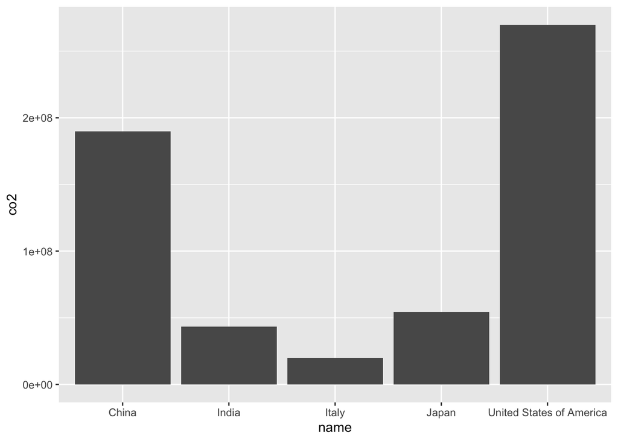

```r
carbonemission <- gapminder %>%
  group_by(co2) %>%
  filter(name == "United States of America" |name == "China" | name == "India" |
           name == "Japan" | name =="Italy")

ggplot(carbonemission) +
  geom_col(aes(x = name, y = co2))
```

Of these 5 countires, the US has the most carbon emissions, then followed by China. Italy has the least CO2 emissions in comparison to the rest.

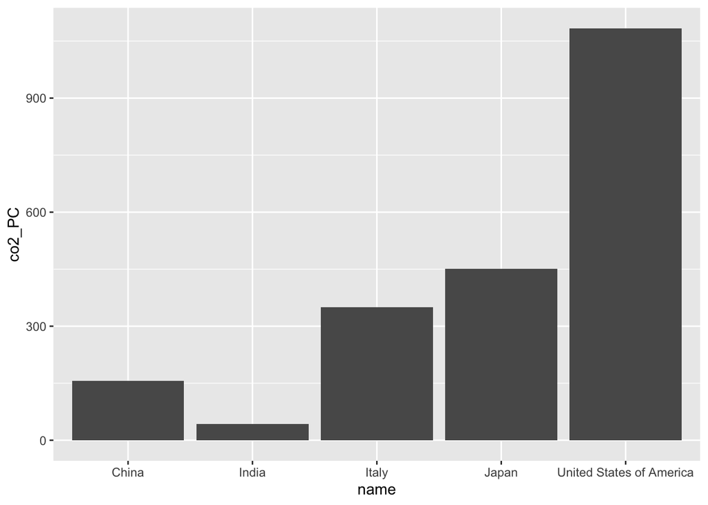

```r
carbonemissionpercap <- gapminder %>%
  group_by(co2_PC) %>%
  filter(name == "United States of America" |name == "China" | name == "India" |
           name == "Japan" | name =="Italy")

ggplot(carbonemissionpercap) +
  geom_col(aes(x = name, y = co2_PC))
```

The **United states** still has the most carbon emissions per capita, meaning that the average person in America will emit more CO2 than the average person of any of the remaining countries. India’s CO2 emission per capita is the lowest because they don’t emit a lot of CO2 in comparison to the US and China and they have a much higher population among most countries.

```r
gapminder %>%
  group_by(region) %>%
  summarise(n = mean(co2_PC, na.rm = TRUE))
```

```
## # A tibble: 6 × 2
##   region        n
##   <chr>     <dbl>
## 1 Africa    0.930
## 2 Americas  6.46
## 3 Asia      6.21
## 4 Europe    7.95
## 5 Oceania   4.39
## 6 <NA>     16.2
```

The average per capita CO2 emissions *over time* indicates that the region, Europe has the highest per capita emission ( if we omit the NA row). Africa is the has the smallest average per capita emission.

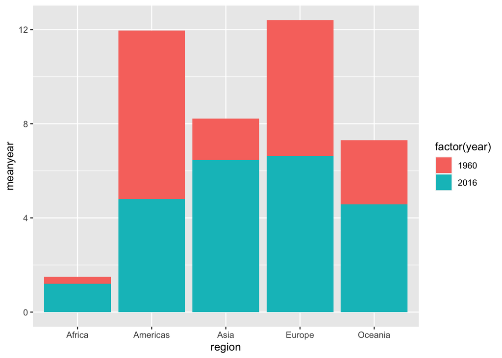

```r
gapminder %>%
  group_by(region) %>%
  filter(!is.na(region)) %>%
  summarise(meanyear = c(mean1960 = mean(co2_PC[time == 1960], na.rm = TRUE),
            mean2016 = mean(co2_PC[time == 2016], na.rm = TRUE)),
            year = c(1960, 2016)) %>%
  ggplot(aes(x = region, y = meanyear, fill = factor(year))) +
    geom_col()
```

```r
max3 <- gapminder %>%
  group_by(region, name) %>%
  filter(!is.na(region)) %>%
  summarize(co22016 = co2_PC[time == 2016])
```

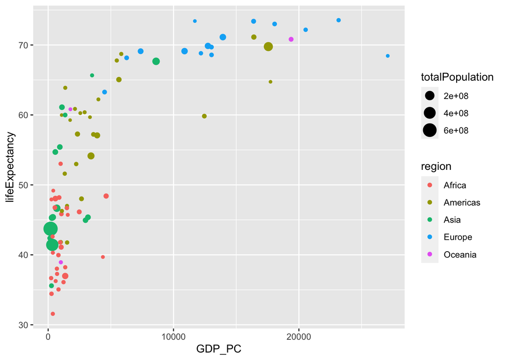

```r
gapminder %>%
  group_by(name) %>%
  filter(time == 1960) %>%
  summarize(GDP_PC, lifeExpectancy, totalPopulation, region) %>%
  drop_na() %>%
  ggplot() +
  geom_point(aes(x= GDP_PC, y= lifeExpectancy, size = totalPopulation, color = region))
```

I plotted country size based on country population beacuse it is not clear what factor we should use to measure country size.

General patterns that I see is that all countries in Europe have an almost horizontal relationship, meaning that the life expectancy is consistent throughout the continent. The largest points are from Asia meaning that they are home to a higher population size. Asia has a lower GDP per capita in general but fluctuate in life expectancy. Africa is clustered in the bottom left corner which indicates they have a low GDP per capita and a low life expectancy.

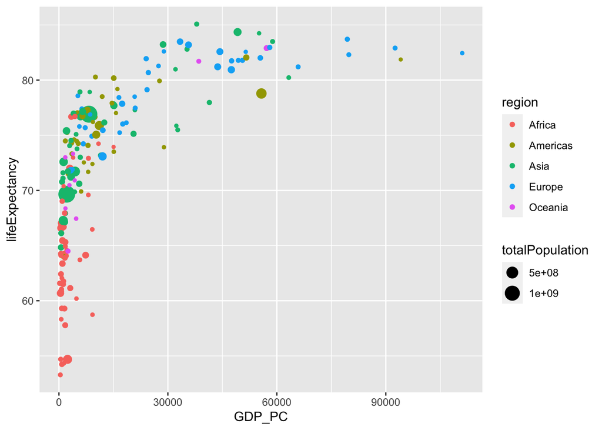

```r
gapminder %>%
  group_by(name) %>%
  filter(time == 2019) %>%
  summarize(GDP_PC, lifeExpectancy, totalPopulation, region) %>%
  drop_na() %>%
  ggplot() +
  geom_point(aes(x= GDP_PC, y= lifeExpectancy, size = totalPopulation, color = region))
```

When comparing these two plots, in general there are more countries that have a higher life expectancy. There is similarities in that Europe still has a slight horizontal relationship with a higher life expectancy. The curve remains the same between the two plots, so it makes me wonder if the world has really made significant improvements.

```r
gapminder %>%
  group_by(region) %>%
  filter(!is.na(region)) %>%
  summarise(life1960 = mean(lifeExpectancy[time == 1960], na.rm = TRUE),
            life2019 = mean(lifeExpectancy[time == 2016], na.rm = TRUE))
```

```
## # A tibble: 5 × 3
##   region   life1960 life2019
##   <chr>       <dbl>    <dbl>
## 1 Africa       41.5     63.0
## 2 Americas     58.6     75.3
## 3 Asia         51.6     74.0
## 4 Europe       68.3     79.0
## 5 Oceania      56.4     73.0
```

yes the results are expected because from this data we can see that the average life expectancy increased for all 5 different regions. The plot indicates that there are more countries with generally higher life expectancies. There is more consistency with the high life expectancy.

```r
gapminder %>%
  group_by(region) %>%
  filter(!is.na(region)) %>%
  mutate(prev = lag(lifeExpectancy),
            growth = (lifeExpectancy - prev),
            avgLEgrowth = mean(growth, na.rm = TRUE)) %>%
  summarize(avgLEgrowth)
```

```
## # A tibble: 12,814 × 2
## # Groups:   region [5]
##    region avgLEgrowth
##    <chr>        <dbl>
##  1 Africa      0.0438
##  2 Africa      0.0438
##  3 Africa      0.0438
##  4 Africa      0.0438
##  5 Africa      0.0438
##  6 Africa      0.0438
##  7 Africa      0.0438
##  8 Africa      0.0438
##  9 Africa      0.0438
## 10 Africa      0.0438
## # … with 12,804 more rows
```

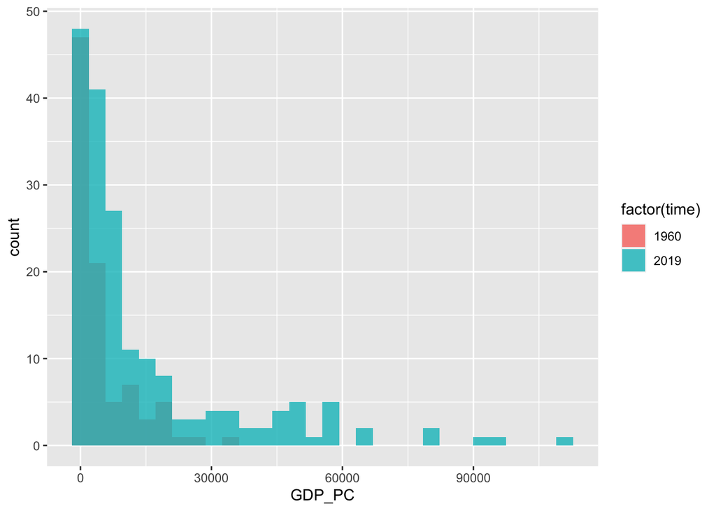

```r
gapminder %>%
  group_by(time) %>%
  filter(time == 1960 | time == 2019) %>%
  summarize(GDP_PC, time) %>%
  drop_na() %>%
  ggplot(aes(x = GDP_PC, fill = factor(time))) +
  geom_histogram(position = "identity", alpha = 0.8, bins = 30)
```

This histogram helps see the improvement of GDP per capita. For each value of GDP, there is a higher frequency of it. This shows the overall improvements of GDP between 1960 and 2019.

```r
gapminder %>%
  filter(time == 1960) %>%
  mutate(rank = rank(-lifeExpectancy)) %>%
  filter(name == "United States of America") %>%
  summarize(rank)
```

```
## # A tibble: 1 × 1
##    rank
##   <dbl>
## 1    18
```

```r
gapminder %>%
  filter(time == 2019) %>%
  mutate(rank = rank(-lifeExpectancy)) %>%
  filter(name == "United States of America") %>%
  summarize(rank)
```

```
## # A tibble: 1 × 1
##    rank
##   <dbl>
## 1    47
```

In 1960, the ranking of the US from the top life expectancy is 18, while in 2019 it is 47. The PS says that the ranking in 1960 should be 17, but I am unsure why I get 18.

```r
gapminder %>%
  filter(time == 2019) %>%
  mutate(rank = rank(-lifeExpectancy),
         smallerrank = (rank/n_distinct(name))) %>%
  filter(name == "United States of America") %>%
  summarize(smallerrank)
```

```
## # A tibble: 1 × 1
##   smallerrank
##         <dbl>
## 1       0.220
```

this problem set was super confusing/hard for me. I spent a whole day on it and I still didnt finish.